# p8105_hw6_ew2718

Emma Warshaw

2022-11-28

##Problem 2

The Washington Post has gathered data on homicides in 50 large U.S. cities and made the data available through a GitHub repository here. You can read their accompanying article here.

Create a city_state variable (e.g. “Baltimore, MD”), and a binary variable indicating whether the homicide is solved. Omit cities Dallas, TX; Phoenix, AZ; and Kansas City, MO – these don’t report victim race. Also omit Tulsa, AL – this is a data entry mistake. For this problem, limit your analysis those for whom victim_race is white or black. Be sure that victim_age is numeric.

```r
homicide_data = read_csv("https://raw.githubusercontent.com/washingtonpost/data-homicides/master/homicide-data.csv")
my_homicide_df = homicide_data %>%
  mutate(city_state = str_c(city, state, sep = ",")) %>%
  mutate(solved_status = ifelse(disposition %in% c("Closed without arrest", "Open/No arrest"), 0 , 1)) %>%
  mutate(victim_age = as.numeric(victim_age)) %>%
  filter(
    city_state != "Dallas,TX",
    city_state != "Phoenix,AZ",
    city_state != "Kansas City,MO",
    city_state != "Tulsa,AL") %>%
  filter(victim_race %in% c("White", "Black"))
```

For the city of Baltimore, MD, use the glm function to fit a logistic regression with resolved vs unresolved as the outcome and victim age, sex and race as predictors. Save the output of glm as an R object; apply the broom::tidy to this object; and obtain the estimate and confidence interval of the adjusted odds ratio for solving homicides comparing male victims to female victims keeping all other variables fixed.

```r
baltimore_reg = my_homicide_df %>%
  filter(
    city_state == "Baltimore,MD"
  ) %>%
  mutate(
    victim_sex = fct_relevel(victim_sex, "Male"))

fit_model_baltimore = baltimore_reg %>%
  glm(solved_status ~ victim_age + victim_sex + victim_race, data = ., family = binomial())

baltimore_model_stats_sex = fit_model_baltimore %>%
  broom::tidy() %>%
  mutate(
    OR = exp(estimate),
    lower_ci = exp(estimate - 1.96*std.error),
    upper_ci = exp(estimate + 1.96*std.error)) %>%
  select(term, estimate, OR, lower_ci, upper_ci) %>%
  filter(term == "victim_sexFemale")

baltimore_model_stats_sex %>%
  knitr::kable(digits = 3)
```

| term | estimate | OR | lower_ci | upper_ci |
| --- | --- | --- | --- | --- |
| victim_sexFemale | 0.854 | 2.35 | 1.793 | 3.081 |

```r
save(baltimore_model_stats_sex, file = "balitmore_model_stats_sex")
```

Now run glm for each of the cities in your dataset, and extract the adjusted odds ratio (and CI) for solving homicides comparing male victims to female victims. Do this within a “tidy” pipeline, making use of purrr::map, list columns, and unnest as necessary to create a dataframe with estimated ORs and CIs for each city.

```r
homicide_all =
  my_homicide_df %>%
  nest(data = -city_state) %>%
  mutate(model = map(data, ~glm(solved_status ~ victim_age + victim_sex + victim_race, data = .x, family = binomial())),
         results = map(model, broom::tidy)) %>%
  select(-data, -model) %>%
  unnest(results) %>%
  filter(term == "victim_sexMale") %>%
  select(city_state, term, estimate, std.error) %>%
  mutate(
    odds_ratio = exp(estimate),
    low_conf = exp(estimate - 1.96*std.error),
    upper_conf = exp(estimate + 1.96*std.error)) %>%
  select(-estimate, -std.error)
```

Create a plot that shows the estimated ORs and CIs for each city. Organize cities according to estimated OR, and comment on the plot.

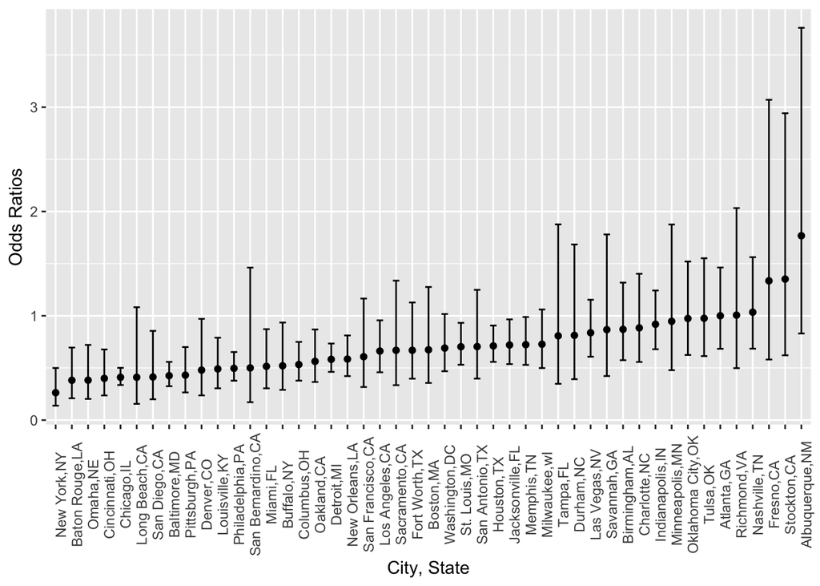

```r
homicide_all %>%
  mutate(city_state = fct_reorder(city_state, odds_ratio)) %>%
  ggplot(aes(x = city_state, y = odds_ratio)) +
  geom_point() +
  geom_errorbar(aes(ymin = low_conf, ymax = upper_conf), width = 0.4) +
  theme(legend.position = "none", axis.text.x = element_text(angle = 90)) +
  labs(
    x = "City, State",
    y = "Odds Ratios"
  )
```

This plot shows the odds that a crime is solved for male victims compared to female victims. For a city like New York, the odds of an solved crime for males is significantly lower than for female victims. At the same time, for the cities that appear to have higher odds ratios, like Albuquerque, the confidence interval also crosses the null value of 1, meaning that gender isn’t necessarily a good predictor of the outcome in these cities. For the cities with significant odds ratios (i.e. don’t cross the null value), the odds of a solved crime are generally lower for males when compared to females.

##Problem 3

Load and clean the data for regression analysis (i.e. convert numeric to factor where appropriate, check for missing data, etc.).

```r
birthweight_data = read_csv("./data/birthweight.csv")
birthweight_data %>%
  mutate(
    babysex = as.factor(babysex),
    frace = as.factor(frace),
    malform = as.factor(malform),
    mrace = as.factor(mrace))
```

```
## # A tibble: 4,342 × 20
##    babysex bhead blength   bwt delwt fincome frace gaweeks malform menarche
##    <fct>   <dbl>   <dbl> <dbl> <dbl>   <dbl> <fct>   <dbl> <fct>      <dbl>
##  1 2          34      51  3629   177      35 1        39.9 0             13
##  2 1          34      48  3062   156      65 2        25.9 0             14
##  3 2          36      50  3345   148      85 1        39.9 0             12
##  4 1          34      52  3062   157      55 1        40   0             14
##  5 2          34      52  3374   156       5 1        41.6 0             13
##  6 1          33      52  3374   129      55 1        40.7 0             12
##  7 2          33      46  2523   126      96 2        40.3 0             14
##  8 2          33      49  2778   140       5 1        37.4 0             12
##  9 1          36      52  3515   146      85 1        40.3 0             11
## 10 1          33      50  3459   169      75 2        40.7 0             12
## # … with 4,332 more rows, and 10 more variables: mheight <dbl>, momage <dbl>,
## #   mrace <fct>, parity <dbl>, pnumlbw <dbl>, pnumsga <dbl>, ppbmi <dbl>,
## #   ppwt <dbl>, smoken <dbl>, wtgain <dbl>
```

Propose a regression model for birthweight. This model may be based on a hypothesized structure for the factors that underly birthweight, on a data-driven model-building process, or a combination of the two. Describe your modeling process and show a plot of model residuals against fitted values – use add_predictions and add_residuals in making this plot.

```r
birthweight_data %>%
  mutate(
    bwt = bwt*0.00220462
  )
```

```
## # A tibble: 4,342 × 20
##    babysex bhead blength   bwt delwt fincome frace gaweeks malform menarche
##      <dbl> <dbl>   <dbl> <dbl> <dbl>   <dbl> <dbl>   <dbl>   <dbl>    <dbl>
##  1       2    34      51  8.00   177      35     1    39.9       0       13
##  2       1    34      48  6.75   156      65     2    25.9       0       14
##  3       2    36      50  7.37   148      85     1    39.9       0       12
##  4       1    34      52  6.75   157      55     1    40         0       14
##  5       2    34      52  7.44   156       5     1    41.6       0       13
##  6       1    33      52  7.44   129      55     1    40.7       0       12
##  7       2    33      46  5.56   126      96     2    40.3       0       14
##  8       2    33      49  6.12   140       5     1    37.4       0       12
##  9       1    36      52  7.75   146      85     1    40.3       0       11
## 10       1    33      50  7.63   169      75     2    40.7       0       12
## # … with 4,332 more rows, and 10 more variables: mheight <dbl>, momage <dbl>,
## #   mrace <dbl>, parity <dbl>, pnumlbw <dbl>, pnumsga <dbl>, ppbmi <dbl>,
## #   ppwt <dbl>, smoken <dbl>, wtgain <dbl>
```

```r
my_model_birthweight = lm(bwt ~ parity + wtgain + momage + fincome, data = birthweight_data)

my_model_plot = birthweight_data %>%
  add_residuals(my_model_birthweight, var = "residuals") %>%
  add_predictions(my_model_birthweight, var = "fitted_values") %>%
  ggplot(aes(x = fitted_values, y = residuals)) +
  geom_point() +
  geom_smooth(method = lm, formula = y~x)
  labs(
    title = "Plot: Residuals Against Fitted Values for My Model",
    x = "fitted values",
    y = "residuals"
  )
```

```
## $x
## [1] "fitted values"
##
## $y
## [1] "residuals"
##
## $title
## [1] "Plot: Residuals Against Fitted Values for My Model"
##
## attr(,"class")
## [1] "labels"
```

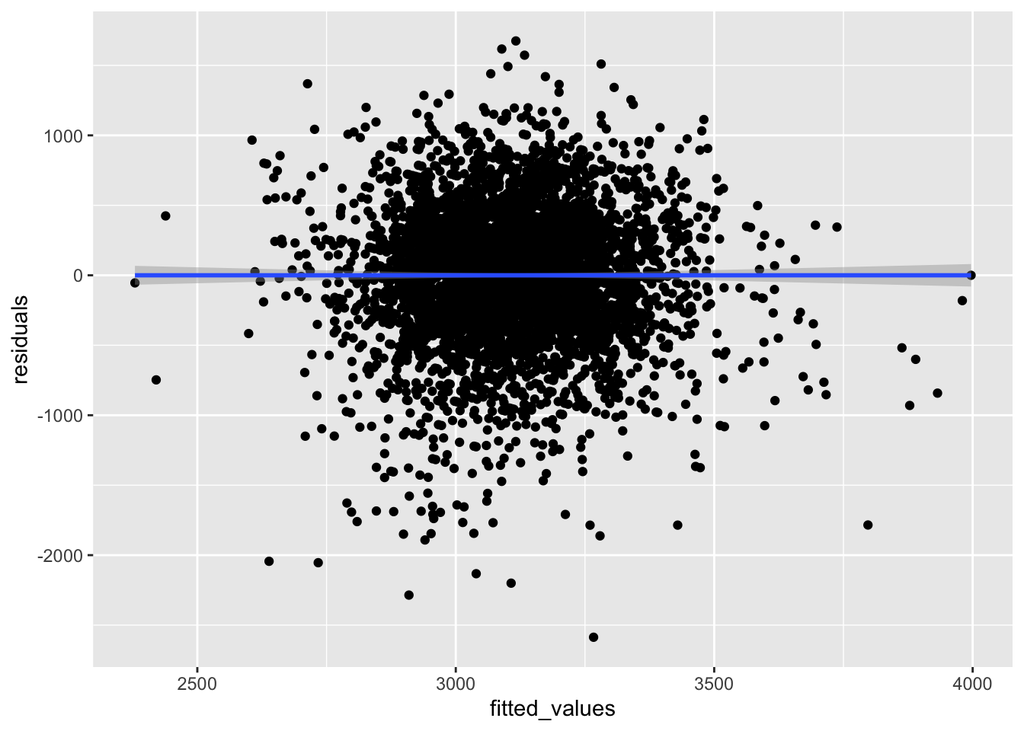

```r
my_model_plot
```

Compare your model to two others:

One using length at birth and gestational age as predictors (main effects only).

One using head circumference, length, sex, and all interactions (including the three-way interaction) between these. Make this comparison in terms of the cross-validated prediction error; use crossv_mc and functions in purrr as appropriate.

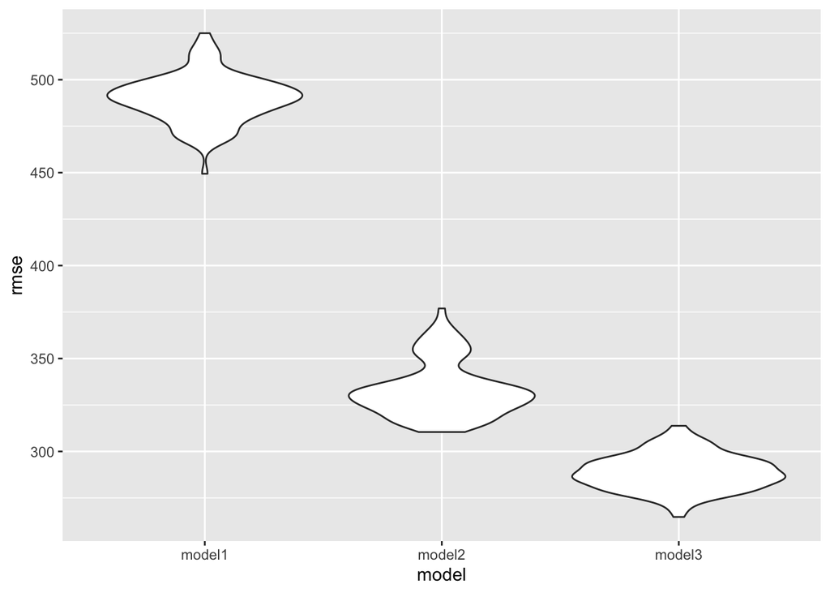

```r
length_age_model = lm(bwt ~ blength + gaweeks, data = birthweight_data)

interaction_model = lm(bwt ~ bhead + blength + babysex + bhead*blength + bhead*babysex + blength*babysex + bhead*blength*babysex, data = birthweight_data)

compare_models =
  crossv_mc(birthweight_data, 100) %>%
  mutate(
    train = map(train, as_tibble),
    test = map(test, as_tibble)
  ) %>%
  mutate(
    model_1 = map(train, ~lm(bwt ~ parity + wtgain + momage + fincome, data = .x)),
    model_2 = map(train, ~lm(bwt ~ blength + gaweeks, data = .x)),
    model_3 = map(train, ~lm(bwt ~ bhead + blength + babysex + bhead*blength + bhead*babysex + blength*babysex + bhead*blength*babysex, data =.x))
  ) %>%
  mutate(
    rmse_model1 = map2_dbl(model_1, test, ~rmse(model = .x, data = .y)),
    rmse_model2 = map2_dbl(model_2, test, ~rmse(model = .x, data = .y)),
    rmse_model3 = map2_dbl(model_3, test, ~rmse(model = .x, data = .y)))
compare_models %>%
  select(starts_with("rmse")) %>%
  pivot_longer(
    everything(),
    names_to = "model",
    values_to = "rmse",
    names_prefix = "rmse_") %>%
  mutate(model = fct_inorder(model)) %>%
  ggplot(aes(x = model, y = rmse)) + geom_violin()
```

Model 3, or the model with the interaction values is the best fit of these options. My model (model 1) is by far the worst.